# Assignment 1: Partial Least Squares

Nina van Gerwen (1860852)

2022-11-29

## 1: Partial Least Squares

### 1.1: Loading the data

```r
## We load the data through readRDS
corn <- readRDS("data/corn.rds")
```

### 1.2: Picking a property

```r
## To get the desccriptives of the four properties, we use summary()
summary(corn[, 1:4])
```

```
##     Moisture           Oil           Protein          Starch
##  Min.   : 9.377   Min.   :3.088   Min.   :7.654   Min.   :62.83
##  1st Qu.: 9.956   1st Qu.:3.406   1st Qu.:8.287   1st Qu.:64.26
##  Median :10.283   Median :3.497   Median :8.562   Median :64.82
##  Mean   :10.234   Mean   :3.498   Mean   :8.668   Mean   :64.70
##  3rd Qu.:10.466   3rd Qu.:3.642   3rd Qu.:9.019   3rd Qu.:65.35
##  Max.   :10.993   Max.   :3.832   Max.   :9.711   Max.   :66.47
```

After looking at the descriptive statistics of the four variables, I have decided to chosen to predict the property of *Moisture*.

### 1.3: Splitting the dataset

```r
## First, set a seed for reproducibility
set.seed(1248)

## Then, give corn a new variable split, which is a variable that is
## sampled with replacement from the two options "train" and "test" with
## .8 and .2 probability
corn$split <- sample(c("train", "test"), size = nrow(corn), replace = TRUE,
                     prob = c(.8, .2))

## Finally, the training data will be the subset of corn, where they
## were sampled to train, and we remove the split variable
train_data <- subset(corn, split == "train", -split)
## And of course, the test data will be the subset of corn, where they
## were sampled to test, and we again remove the split variable
test_data <- subset(corn, split == "test", -split)
```

### 1.4: Estimating a partial least squares model

```r
## Load the pls package
library(pls, warn.conflicts = FALSE)

## Now we run the PLS model through the plsr function
## We remove the other features from the formula, set scale = TRUE
## to make sure all features are on the same scale and finally
## we state that for validation we want leave one out
pls_model <- plsr(Moisture ~ .-Oil-Protein-Starch, data = train_data,
                  scale = TRUE, validation = "LOO")
```

### 1.5: Finding the best component

```r
## To find the best component, we look at the Y loadings of the model
pls_model$Yloadings
```

```
##
## Loadings:
##          Comp 1 Comp 2 Comp 3 Comp 4 Comp 5 Comp 6 Comp 7 Comp 8 Comp 9 Comp 10
## Moisture               0.115  0.178  0.213  0.218  0.353  0.469  0.521  0.630
##          Comp 11 Comp 12 Comp 13 Comp 14 Comp 15 Comp 16 Comp 17 Comp 18
## Moisture 0.809   0.421   0.491   0.670   1.211   1.533   0.922   0.867
##          Comp 19 Comp 20 Comp 21 Comp 22 Comp 23 Comp 24 Comp 25 Comp 26
## Moisture 0.946   2.413   2.365   1.851   0.937   1.729   1.569   3.748
##          Comp 27 Comp 28 Comp 29 Comp 30 Comp 31 Comp 32 Comp 33 Comp 34
## Moisture 3.598   1.573   2.307   1.502   1.140   1.291   1.677   2.485
##          Comp 35 Comp 36 Comp 37 Comp 38 Comp 39 Comp 40 Comp 41 Comp 42
## Moisture 0.810   0.612   0.706   0.359   0.245   0.218   0.233
##          Comp 43 Comp 44 Comp 45 Comp 46 Comp 47 Comp 48 Comp 49 Comp 50
## Moisture
##          Comp 51 Comp 52 Comp 53 Comp 54 Comp 55 Comp 56 Comp 57 Comp 58
## Moisture
##          Comp 59
## Moisture
##
##                Comp 1 Comp 2 Comp 3 Comp 4 Comp 5 Comp 6 Comp 7 Comp 8 Comp 9
## SS loadings         0  0.003  0.013  0.032  0.045  0.048  0.125  0.220  0.271
## Proportion Var      0  0.003  0.013  0.032  0.045  0.048  0.125  0.220  0.271
## Cumulative Var      0  0.003  0.016  0.048  0.093  0.141  0.265  0.486  0.757
##                Comp 10 Comp 11 Comp 12 Comp 13 Comp 14 Comp 15 Comp 16 Comp 17
## SS loadings      0.397   0.655   0.177   0.241   0.449   1.466   2.351   0.849
## Proportion Var   0.397   0.655   0.177   0.241   0.449   1.466   2.351   0.849
## Cumulative Var   1.154   1.808   1.986   2.227   2.676   4.142   6.493   7.342
##                Comp 18 Comp 19 Comp 20 Comp 21 Comp 22 Comp 23 Comp 24 Comp 25
## SS loadings      0.751   0.894   5.823   5.594   3.427   0.878   2.989    2.46
## Proportion Var   0.751   0.894   5.823   5.594   3.427   0.878   2.989    2.46
## Cumulative Var   8.094   8.988  14.811  20.405  23.832  24.710  27.699   30.16
##                Comp 26 Comp 27 Comp 28 Comp 29 Comp 30 Comp 31 Comp 32 Comp 33
## SS loadings     14.047  12.947   2.473   5.324   2.255   1.300   1.667   2.813
## Proportion Var  14.047  12.947   2.473   5.324   2.255   1.300   1.667   2.813
## Cumulative Var  44.207  57.154  59.628  64.952  67.207  68.507  70.174  72.987
##                Comp 34 Comp 35 Comp 36 Comp 37 Comp 38 Comp 39 Comp 40 Comp 41
## SS loadings      6.175   0.656   0.374   0.499   0.129    0.06   0.047   0.054
## Proportion Var   6.175   0.656   0.374   0.499   0.129    0.06   0.047   0.054
## Cumulative Var  79.162  79.818  80.192  80.691  80.820   80.88  80.927  80.982
##                Comp 42 Comp 43 Comp 44 Comp 45 Comp 46 Comp 47 Comp 48 Comp 49
## SS loadings      0.008   0.004   0.001   0.001   0.000   0.000   0.000   0.000
## Proportion Var   0.008   0.004   0.001   0.001   0.000   0.000   0.000   0.000
## Cumulative Var  80.990  80.994  80.995  80.997  80.997  80.997  80.997  80.997
##                Comp 50 Comp 51 Comp 52 Comp 53 Comp 54 Comp 55 Comp 56 Comp 57
## SS loadings      0.000   0.000   0.000   0.000   0.000   0.000   0.000   0.000
## Proportion Var   0.000   0.000   0.000   0.000   0.000   0.000   0.000   0.000
## Cumulative Var  80.997  80.997  80.997  80.997  80.997  80.997  80.997  80.997
##                Comp 58 Comp 59
## SS loadings      0.000   0.000
## Proportion Var   0.000   0.000
## Cumulative Var  80.997  80.997
```

```r
which.max(pls_model$Yloadings)
```

```
## [1] 26
```

Inspecting the Yloadings element of the Partial Least Squares method, we can find the proportion of variance each component explains for the outcome variable. From this, we find that the 26th component explains the highest Proportion of Variance (*14.05*%).

### 1.6: Visualisation

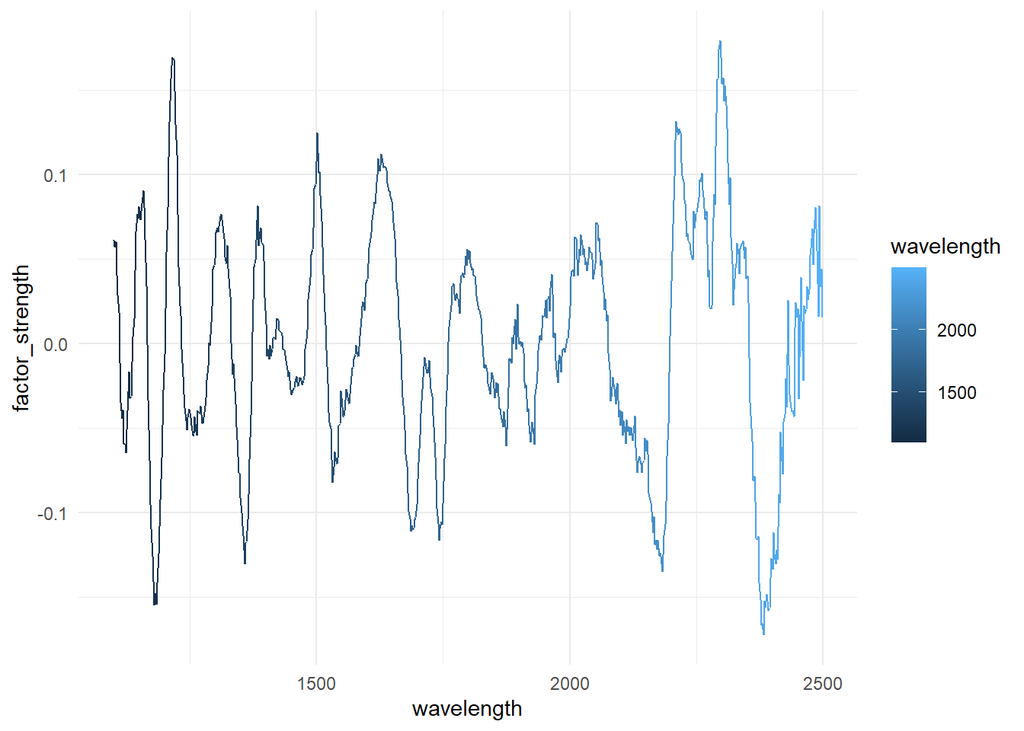

```r
## Load required packages for plotting
library(ggplot2)
library(magrittr)
library(tidyverse)
## Create a plot, where the dataframe is the wavelengths (i.e., the colnames)
## and the factor X loadings for the 26th component
plot <- as.data.frame(cbind(wavelength = as.numeric(colnames(train_data[, 5:704])),
              factor_strength = pls_model$loadings[, 26])) %>%
  ## Then, set the correct aesthetics
  ggplot(data = ., aes(x = wavelength, y = factor_strength,
                       col = wavelength)) +
  ## And ask for a line plot with minimal theme
  geom_line() + theme_minimal()

plot
```

```r
## To explore it further, get the same dataset as above,
## arrange it in descending order of factor strength and ask for the
## first 5 values
as.data.frame(cbind(wavelength = as.numeric(colnames(train_data[, 5:704])),
              factor_strength = pls_model$loadings[, 26])) %>%
  arrange(., desc(abs(factor_strength))) %>%
  head(., 5)
```

```
##        wavelength factor_strength
## `2296`       2296       0.1791156
## `2294`       2294       0.1736814
## `2382`       2382      -0.1727343
## `2298`       2298       0.1694602
## `1216`       1216       0.1693457
```

From the data exploration, we find that the 5 wavelengths with the highest absolute strength of loadings for the 26th components are: 1216, 2294, 2296, 2298 and 2382,. Looking at the plot, we find even more support for the notion that wavelengths between approximately 2200 and 2300 are very important. Furthermore, there is also a high peak near 1200. Therefore, these wavelengths are also probably the most important for predicting *Moisture* in corn.

### 1.7: Creating a more parsimonious model and obtaining predictions

```r
## To create a more parsimonious model, we simply copy the previous model
## and only add a new argument which states that the number of components
## selected should be equal to the number of components that had a standard
## deviation higher than 1 in the first model through the selectNcomp function.
par_model <- plsr(Moisture ~ .-Oil-Protein-Starch, data = train_data,
                  scale = TRUE, validation = "LOO",
                  ncomp = selectNcomp(pls_model, method = "onesigma"))

## Then, to get the predicted values, we use the predict function,
## again stating the number of components and stating what the new data is
pred_values_PLS <- predict(par_model, ncomp = selectNcomp(pls_model, method = "onesigma"),
        newdata = test_data)
```

### 1.8: Comparing results of the parsimonious PLS method to LASSO regression

```r
## LASSO regression
## First load the package
library(glmnet, warn.conflicts = FALSE)
## Then, we run the lasso through the cv.glmnet function by specifying
## our X and Y matrices
cv_lasso_mod <- cv.glmnet(x = as.matrix(train_data[, 5:704]),
                          y = as.matrix(train_data$Moisture))

## And we get predicted values for the test data using predict
## with the argument "lambda.min" on s, such that we get predictions from
## the best model
pred_values_las <- predict(cv_lasso_mod, newx = as.matrix(test_data[, 5:704]),
                           s = "lambda.min")
```

```r
## Then, to compare the two models, we create a function that calculates MSE
mse <- function(y_true, y_pred){
  MSE <- sum((y_true - y_pred)^2)/length(y_true)
  return(MSE)
}

## We also create a short 'table' through cbind that shows the predicted values
## for both models and the true scores so that we can visually compare the models
cbind(PLS_pred = pred_values_PLS, pred_values_las, True_Score = test_data$Moisture)
```

```
##        PLS_pred lambda.min True_Score
##  [1,] 10.432455  10.323871     10.292
##  [2,]  9.959929  10.046478      9.739
##  [3,] 10.049485  10.354531      9.978
##  [4,] 10.163911  10.093061      9.857
##  [5,] 10.010663   9.897181     10.034
##  [6,] 10.089399   9.915572     10.069
##  [7,] 10.777232  10.719376     10.747
##  [8,] 10.966542  10.831582     10.936
##  [9,] 10.467811  10.631085     10.525
## [10,] 10.595832  10.632695     10.535
## [11,] 10.481014  10.778758     10.592
## [12,]  9.725039   9.912597      9.817
## [13,] 10.378909  10.470220     10.315
## [14,] 10.198594  10.227003     10.126
## [15,] 10.200954  10.265168     10.025
## [16,] 10.337077  10.168703     10.303
## [17,] 10.191767  10.240755     10.398
## [18,]  9.951950   9.414594      9.377
## [19,] 10.683004  10.546555     10.568
```

```r
## And we calculate the MSE for the predicted values from both models
## using the earlier created mse function
mse(test_data$Moisture, pred_values_PLS)
```

```
## [1] 0.03295767
```

```r
mse(test_data$Moisture, pred_values_las)
```

```
## [1] 0.02886371
```

Comparing the PLS regression predicted values to the LASSO regression on the test set, we find that the predicted values are quite similar to one another with only minor differences. When estimating the mean squared error (MSE), we find that the LASSO regression has the smallest MSE with a value of .029 versus the MSE value of .033 for the PLS regression.